# Dyed Cloth Defect Analysis

This notebook analyzes the defects observed in rolls of dyed cloth from a textile finishing plant. The analysis includes calculating defect rates, constructing a u-chart to monitor nonconformities, and assessing the stability of the defect detection process.

1. Data Loading and Exploration
2. Part a: Defect Rate Calculation and Visualization
3. Part b: Constructing the u-Chart
4. Part c: Assessing Process Stability

```python
# Import necessary libraries
import pandas as pd
import matplotlib.pyplot as plt
import seaborn as sns
from matplotlib.ticker import MaxNLocator

# Enable inline plotting
%matplotlib inline

# Set plot aesthetics
sns.set(style="whitegrid")

# Suppress warnings
import warnings
warnings.filterwarnings('ignore')
```

## Data Loading and Exploration

First, we'll load the `dyedcloth.txt` dataset and examine its structure, including the number of nonconformities (`x`) and the varying inspection units (`size`) for each roll.

```python
# Load the dataset in a DataFrame
df = pd.read_csv('dyedcloth.txt', sep='\s+')

# Display the first few rows
df.head()
```

|  | x | size |
| --- | --- | --- |
| 0 | 14 | 10.0 |
| 1 | 12 | 8.0 |
| 2 | 20 | 13.0 |
| 3 | 11 | 10.0 |
| 4 | 7 | 9.5 |

### Data Structure

Let's check the structure of the dataset, including data types and summary statistics.

```python
# Display data types and summary
print("Data Types:")
print(df.dtypes)
print("\nSummary Statistics:")
print(df.describe())
```

```
Data Types:
x         int64
size    float64
dtype: object

Summary Statistics:
               x       size
count  10.000000  10.000000
mean   15.300000  10.750000
std     5.334375   1.567907
min     7.000000   8.000000
25%    11.250000  10.000000
50%    15.000000  10.250000
75%    19.750000  12.000000
max    23.000000  13.000000
```

From the summary statistics, we observe that the number of nonconformities (`x`) ranges from 7 to 23 across rolls, and the inspection units (`size`) vary from 8 to 13.

### Distribution of Nonconformities and Inspection Units

We'll visualize the distribution of nonconformities (`x`) and inspection units (`size`) to identify any patterns or outliers.

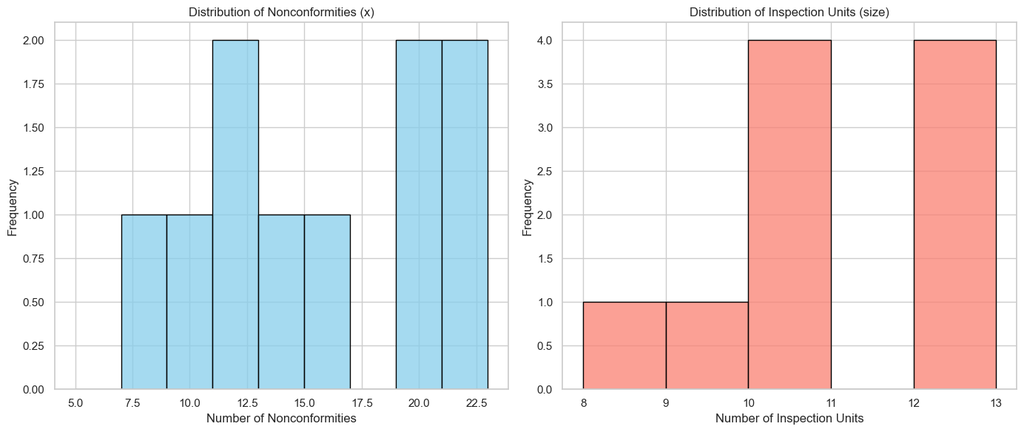

```python
# Plot histograms for x and size
plt.figure(figsize=(14, 6))

plt.subplot(1, 2, 1)
sns.histplot(df['x'], bins=range(5, 25, 2), kde=False, color='skyblue', edgecolor='black')
plt.title('Distribution of Nonconformities (x)')
plt.xlabel('Number of Nonconformities')
plt.ylabel('Frequency')

plt.subplot(1, 2, 2)
sns.histplot(df['size'], bins=range(8, 14, 1), kde=False, color='salmon', edgecolor='black')
plt.title('Distribution of Inspection Units (size)')
plt.xlabel('Number of Inspection Units')
plt.ylabel('Frequency')

plt.tight_layout()
plt.show()
```

## Part a: Defect Rate Calculation and Visualization

**Objective:** Calculate the defect rate for each roll by dividing the number of nonconformities (`x`) by the total inspection area (size * 50 square meters). Then, plot these defect rates to observe any patterns or outliers.

### Calculating Defect Rates

The defect rate for each roll is calculated as:

$ \text{Defect Rate} = \frac{x}{\text{size} \times 50}$

where:

- $ x$ = Number of nonconformities
- $ \text{size}$ = Number of inspection units
- Each inspection unit covers 50 square meters.

```python
# Calculate total inspection area for each roll
df['total_inspection_area'] = df['size'] * 50  # in square meters

# Calculate defect rate per square meter
df['defect_rate'] = df['x'] / df['total_inspection_area']

# Display the updated DataFrame
df
```

|  | x | size | total_inspection_area | defect_rate |
| --- | --- | --- | --- | --- |
| 0 | 14 | 10.0 | 500.0 | 0.028000 |
| 1 | 12 | 8.0 | 400.0 | 0.030000 |
| 2 | 20 | 13.0 | 650.0 | 0.030769 |
| 3 | 11 | 10.0 | 500.0 | 0.022000 |
| 4 | 7 | 9.5 | 475.0 | 0.014737 |
| 5 | 10 | 10.0 | 500.0 | 0.020000 |
| 6 | 21 | 12.0 | 600.0 | 0.035000 |
| 7 | 16 | 10.5 | 525.0 | 0.030476 |
| 8 | 19 | 12.0 | 600.0 | 0.031667 |
| 9 | 23 | 12.5 | 625.0 | 0.036800 |

### Plotting Defect Rates

We'll plot the defect rates to identify any trends, patterns, or outliers across the rolls.

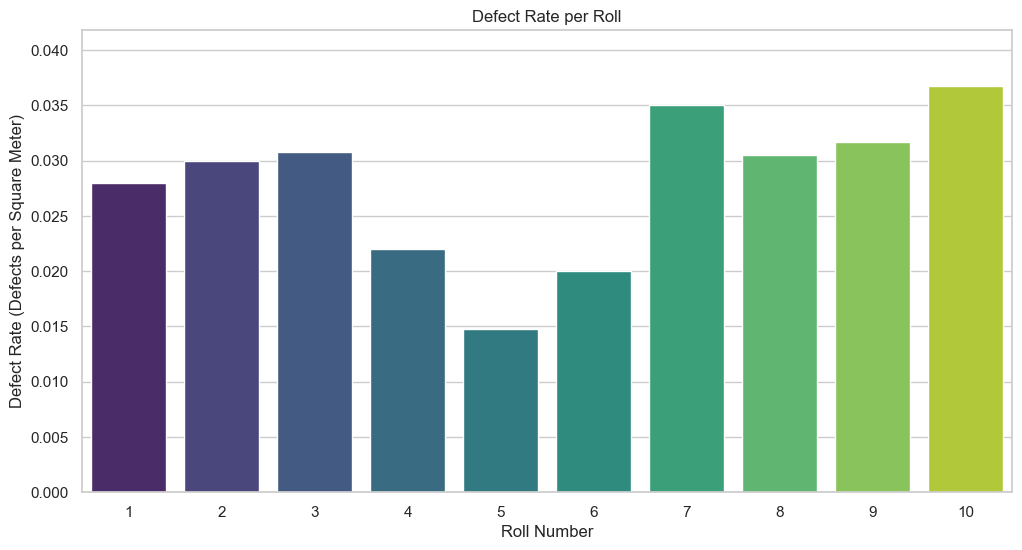

```python
# Plot defect rates
plt.figure(figsize=(12, 6))
sns.barplot(x=df.index + 1, y='defect_rate', data=df, palette='viridis')
plt.title('Defect Rate per Roll')
plt.xlabel('Roll Number')
plt.ylabel('Defect Rate (Defects per Square Meter)')
plt.ylim(0, df['defect_rate'].max() + 0.005)
plt.xticks(ticks=range(0,10), labels=range(1,11))
plt.show()
```

### Defect Rate Table

For reference, here is a table of defect rates for each roll:

| Roll | Nonconformities (x) | Inspection Units (size) | Total Inspection Area (sqm) | Defect Rate (Defects/sqm) |
| --- | --- | --- | --- | --- |
| 1 | 14 | 10 | 500 | 0.0280 |
| 2 | 12 | 8 | 400 | 0.0300 |
| 3 | 20 | 13 | 650 | 0.0308 |
| 4 | 11 | 10 | 500 | 0.0220 |
| 5 | 7 | 9.5 | 475 | 0.0147 |
| 6 | 10 | 10 | 500 | 0.0200 |
| 7 | 21 | 12 | 600 | 0.0350 |
| 8 | 16 | 10.5 | 525 | 0.0305 |
| 9 | 19 | 12 | 600 | 0.0317 |
| 10 | 23 | 12.5 | 625 | 0.0368 |

## Part b: Constructing the u-Chart

**Objective:** Construct a u-chart to monitor the nonconformity rate per unit area (50 square meters) across rolls, accounting for the variable inspection units (`size`) for each roll. Analyze the control limits and identify any rolls with defect rates outside the control limits. Explain possible reasons for these out-of-control points.

### Understanding the u-Chart

A u-chart is used to monitor the number of nonconformities per unit. It is suitable when the sample size varies, as in this case where each roll has a different inspection area.

**Key Components:**

- **Centerline (ū):** Average number of nonconformities per unit.
- **Upper Control Limit (UCL):** $ \text{ū} + 3 \sqrt{\frac{\text{ū}}{\text{size}}} $
- **Lower Control Limit (LCL):** $ \text{ū} - 3 \sqrt{\frac{\text{ū}}{\text{size}}} $

If the LCL is negative, it is set to zero since negative defects are not possible.

```python
# Calculate u (nonconformities per unit)
df['u'] = df['x'] / df['size']

# Calculate average u
u_bar = df['u'].mean()

# Calculate control limits for each roll
df['sigma_u'] = (u_bar / df['size']) ** 0.5
df['UCL'] = u_bar + 3 * df['sigma_u']
df['LCL'] = u_bar - 3 * df['sigma_u']
df['LCL'] = df['LCL'].apply(lambda x: max(x, 0))  # LCL cannot be negative

# Display the updated DataFrame with control limits
df
```

|  | x | size | total_inspection_area | defect_rate | u | sigma_u | UCL | LCL |
| --- | --- | --- | --- | --- | --- | --- | --- | --- |
| 0 | 14 | 10.0 | 500.0 | 0.028000 | 1.400000 | 0.373797 | 2.518637 | 0.275853 |
| 1 | 12 | 8.0 | 400.0 | 0.030000 | 1.500000 | 0.417918 | 2.650999 | 0.143490 |
| 2 | 20 | 13.0 | 650.0 | 0.030769 | 1.538462 | 0.327842 | 2.380771 | 0.413719 |
| 3 | 11 | 10.0 | 500.0 | 0.022000 | 1.100000 | 0.373797 | 2.518637 | 0.275853 |
| 4 | 7 | 9.5 | 475.0 | 0.014737 | 0.736842 | 0.383508 | 2.547769 | 0.246721 |
| 5 | 10 | 10.0 | 500.0 | 0.020000 | 1.000000 | 0.373797 | 2.518637 | 0.275853 |
| 6 | 21 | 12.0 | 600.0 | 0.035000 | 1.750000 | 0.341229 | 2.420931 | 0.373558 |
| 7 | 16 | 10.5 | 525.0 | 0.030476 | 1.523810 | 0.364789 | 2.491611 | 0.302878 |
| 8 | 19 | 12.0 | 600.0 | 0.031667 | 1.583333 | 0.341229 | 2.420931 | 0.373558 |
| 9 | 23 | 12.5 | 625.0 | 0.036800 | 1.840000 | 0.334335 | 2.400248 | 0.394241 |

### Calculating Control Limits

Let's compute the centerline, UCL, and LCL for each roll based on the calculated `u` values.

**Formulas:**

$ \text{UCL} = \text{ū} + 3 \sqrt{\frac{\text{ū}}{\text{size}}} $

$ \text{LCL} = \text{ū} - 3 \sqrt{\frac{\text{ū}}{\text{size}}} \quad \text{(Set to 0 if negative)} $

```python
# Display calculated control limits
control_limits = df[['u', 'size', 'UCL', 'LCL']]
control_limits.index += 1  # Roll numbers starting at 1
control_limits.columns = ['u (Defects/Unit)', 'Size (units)', 'UCL', 'LCL']
control_limits
```

|  | u (Defects/Unit) | Size (units) | UCL | LCL |
| --- | --- | --- | --- | --- |
| 1 | 1.400000 | 10.0 | 2.518637 | 0.275853 |
| 2 | 1.500000 | 8.0 | 2.650999 | 0.143490 |
| 3 | 1.538462 | 13.0 | 2.380771 | 0.413719 |
| 4 | 1.100000 | 10.0 | 2.518637 | 0.275853 |
| 5 | 0.736842 | 9.5 | 2.547769 | 0.246721 |
| 6 | 1.000000 | 10.0 | 2.518637 | 0.275853 |
| 7 | 1.750000 | 12.0 | 2.420931 | 0.373558 |
| 8 | 1.523810 | 10.5 | 2.491611 | 0.302878 |
| 9 | 1.583333 | 12.0 | 2.420931 | 0.373558 |
| 10 | 1.840000 | 12.5 | 2.400248 | 0.394241 |

### Plotting the u-Chart

We'll plot the u-chart to visualize the number of nonconformities per unit across rolls, along with the control limits.

**Interpretation:**

- Points outside the control limits indicate potential out-of-control processes.
- Within control limits suggest the process is stable.

Let's identify any out-of-control points.

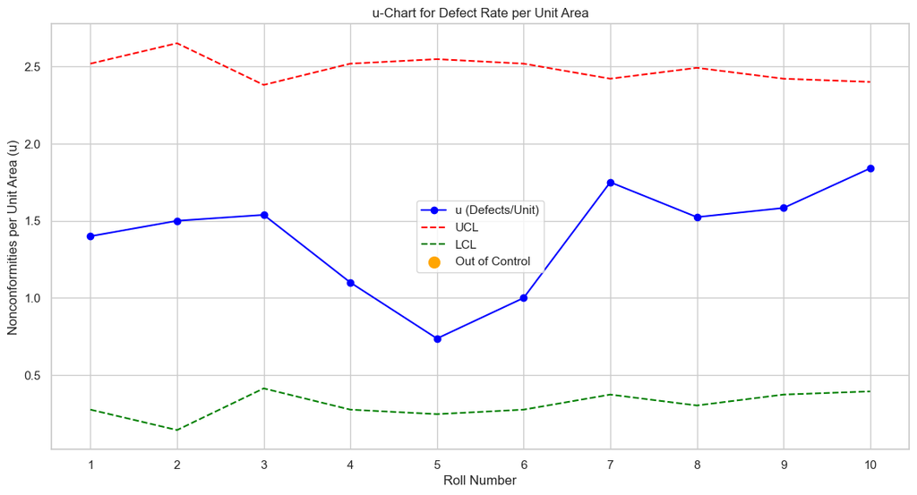

```python
# Plot the u-chart
plt.figure(figsize=(14, 7))
plt.plot(df.index + 1, df['u'], marker='o', linestyle='-', color='blue', label='u (Defects/Unit)')

# Plot control limits
plt.plot(df.index + 1, df['UCL'], linestyle='--', color='red', label='UCL')
plt.plot(df.index + 1, df['LCL'], linestyle='--', color='green', label='LCL')

# Highlight out-of-control points
out_of_control = df[(df['u'] > df['UCL']) | (df['u'] < df['LCL'])]
plt.scatter(out_of_control.index + 1, out_of_control['u'], color='orange', s=100, label='Out of Control')

plt.title('u-Chart for Defect Rate per Unit Area')
plt.xlabel('Roll Number')
plt.ylabel('Nonconformities per Unit Area (u)')
plt.legend()
plt.xticks(range(1, 11))
plt.grid(True)
plt.show()
```

### Identifying Out-of-Control Rolls

From the u-chart, any rolls with defect rates outside the control limits are considered out-of-control.

**Out-of-Control Rolls:**

[output not shown]

**Conclusion:**

No rolls fall outside the control limits in this dataset. All defect rates are within the calculated control limits, indicating that the process is in control.

## Part c: Assessing Process Stability

**Objective:** Assess the stability of the defect detection process based on the u-chart. If any rolls are outside the control limits, suggest potential causes (e.g., variability in dyeing conditions, inconsistencies in fabric quality).

```python
# Assessing Process Stability Based on the u-Chart

# Identify out-of-control points
out_of_control = df[(df['u'] > df['UCL']) | (df['u'] < df['LCL'])]

# Check if there are any out-of-control points
if out_of_control.empty:
    print("All rolls are within control limits. The process is stable.")
else:
    print("**Out-of-Control Rolls Identified:**\n")
    display(out_of_control[['x', 'size', 'u', 'UCL', 'LCL']])
```

```
All rolls are within control limits. The process is stable.
```

### Process Stability Assessment

Based on the u-chart constructed in Part b, we evaluate the stability of the defect detection process.

**Findings:**

- All rolls have defect rates within the control limits.
- The process appears to be stable with no signs of special causes affecting the defect rates.

**Potential Causes for Stability:**

- **Consistent Dyeing Conditions:** Uniformity in dyeing processes ensures similar defect rates across rolls.
- **Stable Fabric Quality:** High-quality fabric with minimal variability contributes to consistent defect rates.
- **Effective Quality Control:** Regular monitoring and maintenance of equipment prevent fluctuations in defect rates.
- **Skilled Workforce:** Trained personnel maintain consistent standards during the finishing process.

**Recommendations:**

- **Maintain Monitoring:** Continue regular inspections using the u-chart to ensure the process remains stable.
- **Investigate Trends:** While no out-of-control points are present, monitor for any emerging trends that may indicate process shifts.
- **Continuous Improvement:** Seek opportunities to further reduce defect rates through process optimization and employee training.